# Simulation test using Operating Model based on Life History

Biomass Dynamic

L Kell

16 November, 2018

## Simulation tests

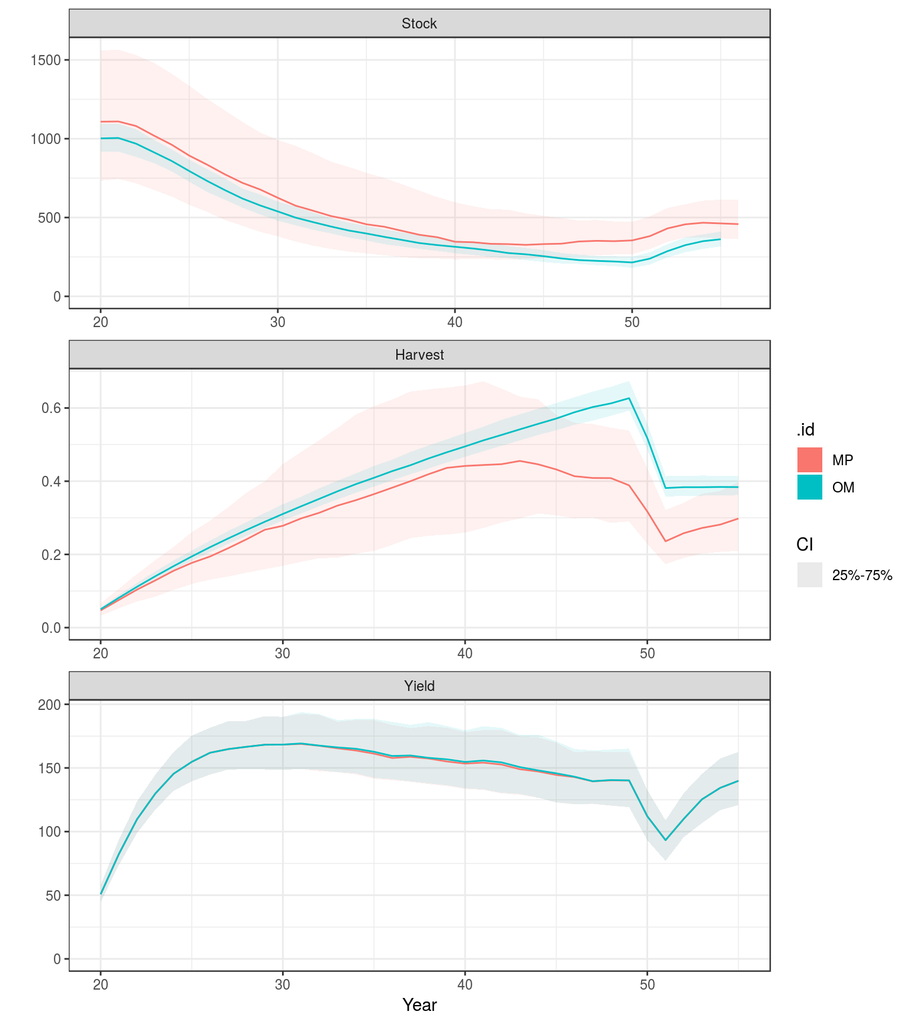

**Figure 1,** Simulation test of biomass dyanmic assessment for brill.

### Turbot

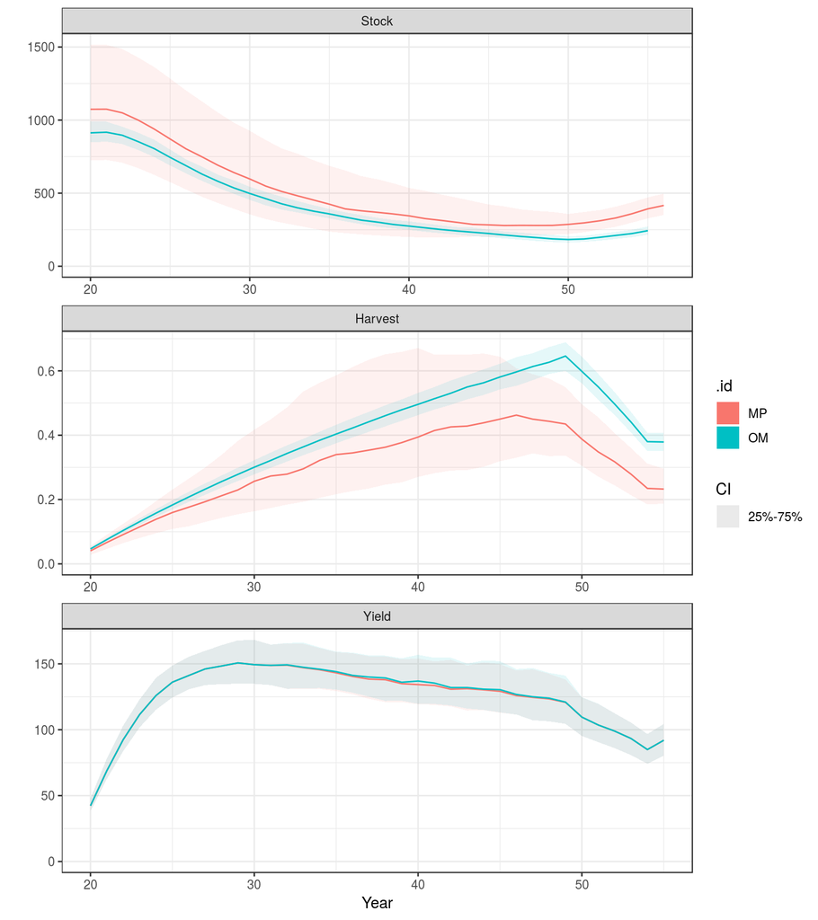

**Figure 2,** Simulation test of biomass dyanmic assessment for turbot.

### Ray

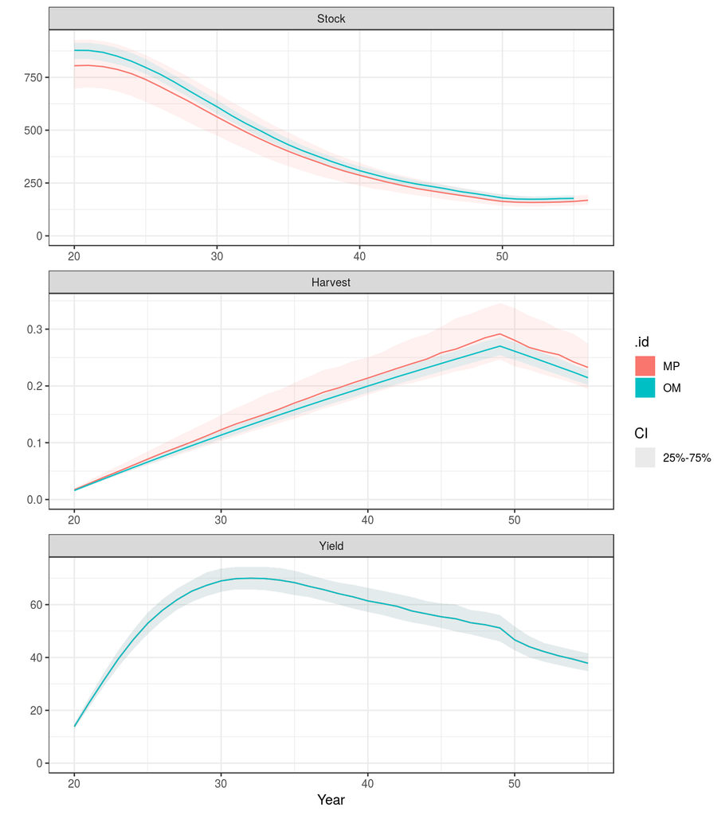

**Figure 3,** Simulation test of biomass dyanmic assessment for ray.

### Pollack

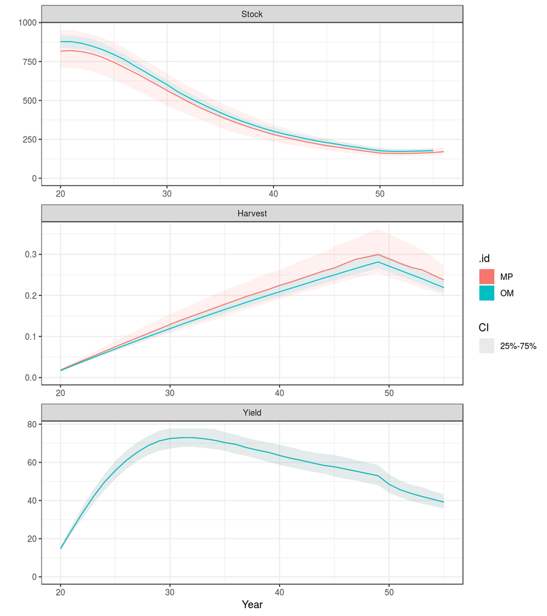

**Figure 4,** Simulation test of biomass dyanmic assessment for pollack.

### Sprat

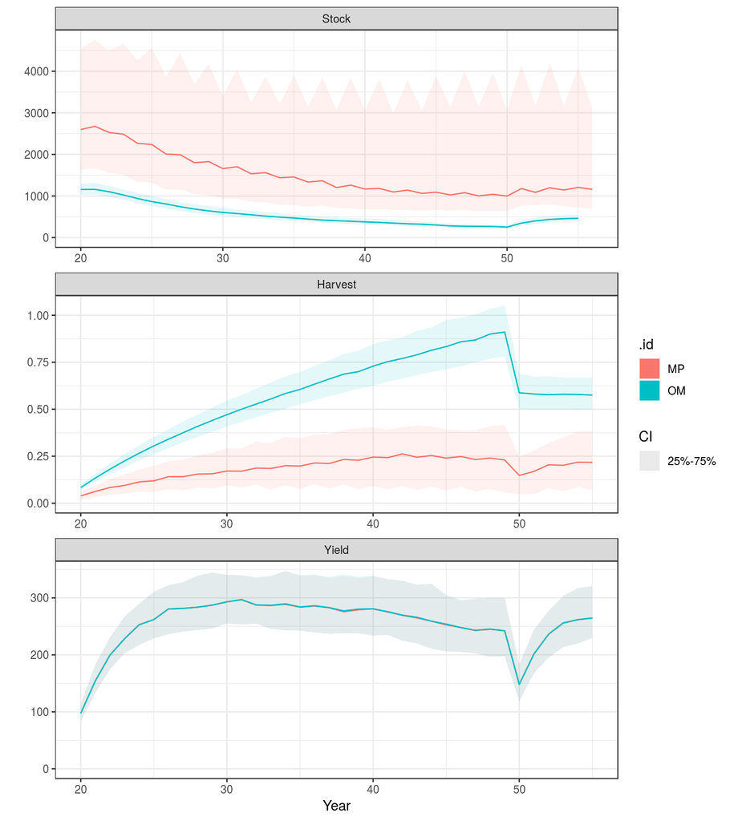

**Figure 5,** Simulation test of biomass dyanmic assessment for sprat.

### Lobster

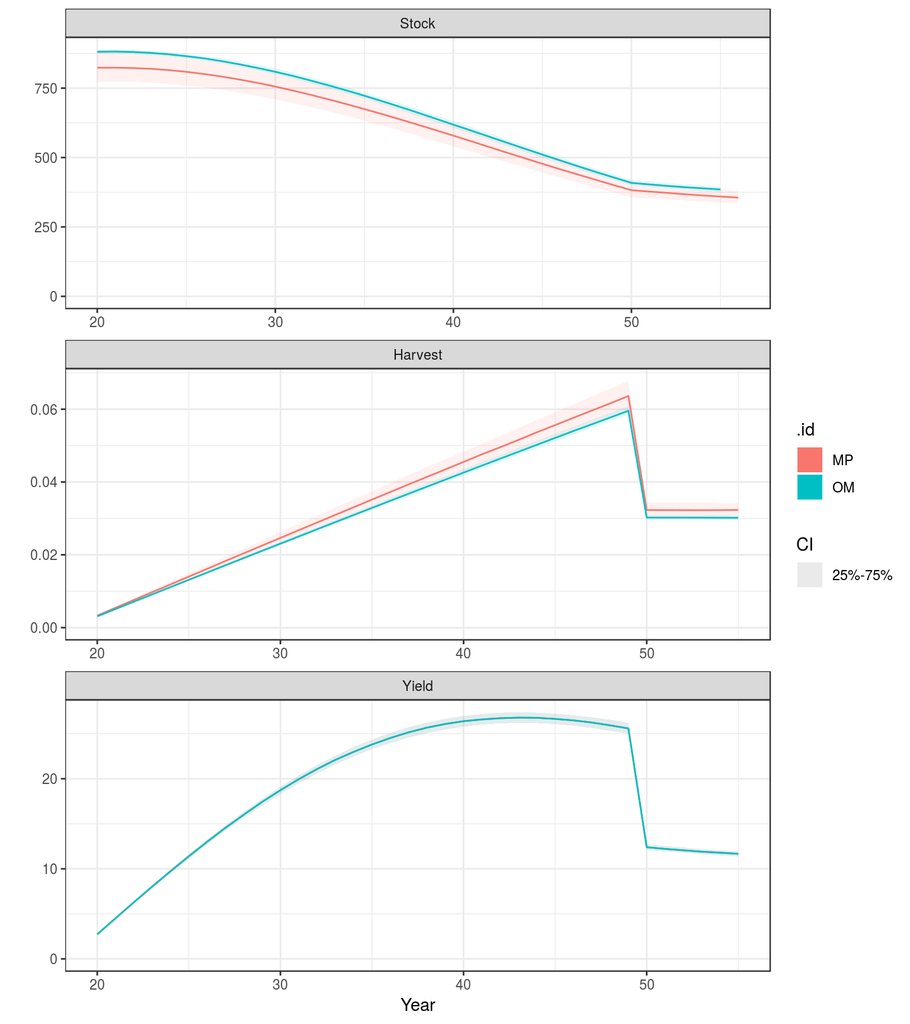

**Figure 6,** Simulation test of biomass dyanmic assessment for lobster.

### Razor

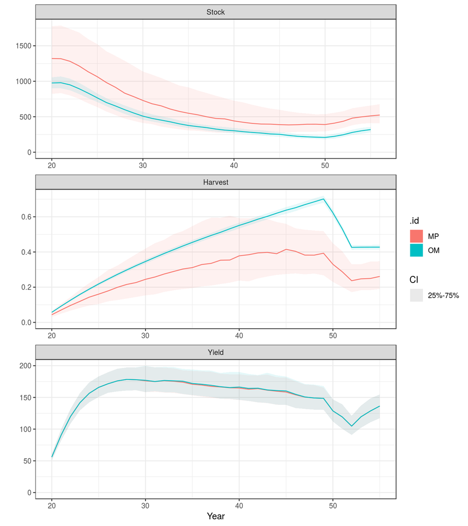

**Figure 7,** Simulation test of biomass dyanmic assessment for razor.

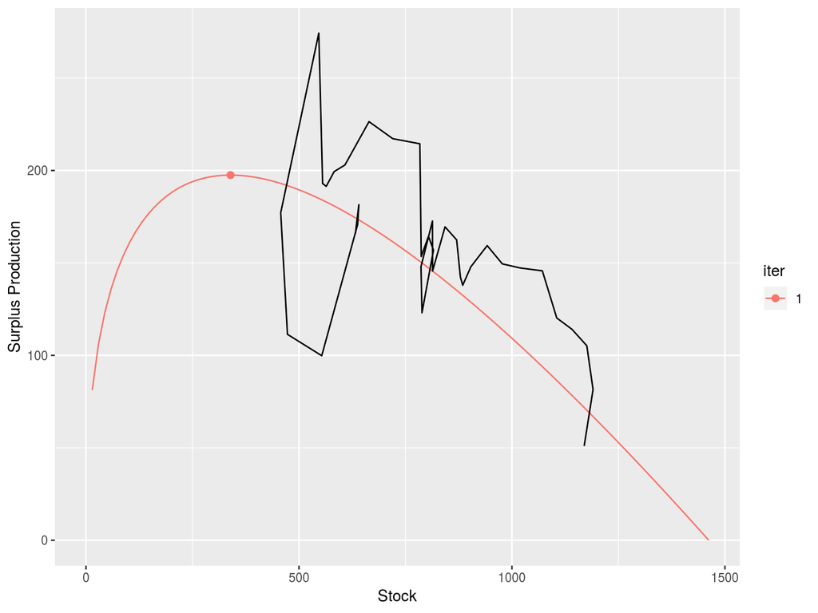

**Figure 8,** Biomass dynamic production function.

## Software Versions

- R version 3.4.4 (2018-03-15)
- FLCore: 2.6.9.9009
- FLife: 3.2.1.9001
- FLBRP: 2.5.3.9001
- **Compiled**: Fri Nov 16 14:44:39 2018

## Author information

**Laurence Kell**. laurie@seaplusplus.es

## Acknowledgements

This vignette and many of the methods documented in it were developed under the MyDas project funded by the Irish exchequer and EMFF 2014-2020. The overall aim of MyDas is to develop and test a range of assessment models and methods to establish Maximum Sustainable Yield (MSY) reference points (or proxy MSY reference points) across the spectrum of data-limited stocks.